# Forecasting in IR

02 May 2017

## Why Forecasting?

What do we want to achieve with forecasting?

## Why Forecasting?

**Authors: Scientists, Analysts**

- to get it right
  - value in itself?
- test theories (Friedman, 1966; Ward, 2016)
- Central function of science next to explanation
  - how much can we know?

**Users: Policy makers etc.**

- basis of decision making
  - influence future
  - show alternatives
- Early-Warning
  - Basis for preparation

## Is Forecasting Possible?

Is successful forecasting in international politics possible at all?

## Is Forecasting Possible?

**The Skeptics**

- Politics are like *Clouds* (Almond et al., 1977)
- Non-Linearity
  - limit to conclusions from the past
- *Black swan* (Taleb, 2007)
  - High impact events are often unexpected
  - e.g. discovery of America, Arab Spring

**The Optimists**

- *The poets*
  - Yes, but without probabilities (Scenarios, Mega trends)
- *The mathematicians*
  - Yes, with sufficient data (Chourci, 1974; Ward, 2016)
- With crowds
  - Groups, competitions, markets

## Forecasting methods - overview

1. **Strategic Foresight**
2. **Statistical models**
3. **Forecasting competitions**
4. Intuitive forecasts
5. Expert forecasts
6. Prediction markets
7. Intelligence Estimates

## Strategic Foresight

Example: [European Union in the World 2025](http://www.dahrendorf-forum.eu/wp-content/uploads/2016/05/Dahrendorf_Analysis_EU_2025_15.pdf) by Dahrendorf Forum

- Essentially: Scenario analysis
- originated and widely used in the corporate sector
  - Shell Foresight 1960s (Pierre Wack)

**Advantage:**

- No content restrictions
- consistency of scenarios as key quality criteria

**Disadvantage:**

- No likelihood judgements (policy maker ask for it)
- how can scenarios be verify?

## Statistical Models

Example: *World-Wide Integrated Crisis Early Warning System (W-ICEWS)* [(Preview)](http://nbviewer.jupyter.org/gist/dmasad/f79ce5abfd4fb61d253b)

**Advantage:**

- can be verified
- less decision biases

**Disadvantage:**

- requires measureable events
  - e.g. number of protesters / injured / death
- not applicable to many relevant questions
  - e.g. International Court of Justice decision forecast
- data often not existing / too expensive

## Forecasting competitions

Example: The Good Judgement Project

- for geopolitics relatively new (first in 2011)
- combine individual judgements and track record keeping of formal model
- Researchers: Philip Tetlock and Barbara Mellers

[figure not shown]

## Security Policy Forecasting Tournament

## Security Policy Forecasting Tournament

- 231 participants in total
  - 53 Hertie students participated (48 on time, 5 late)
- short-term: 2.5 months
  - other tournaments include question up to one / one and a half years
- 24 questions
  - restricted to topics of the Security Policy class
  - questions were externally reviewed before the tournament

## Performance

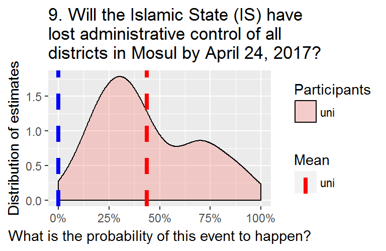

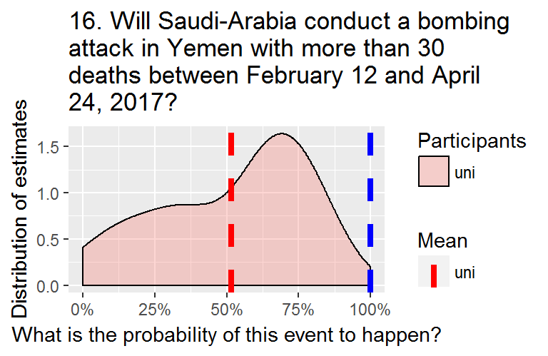

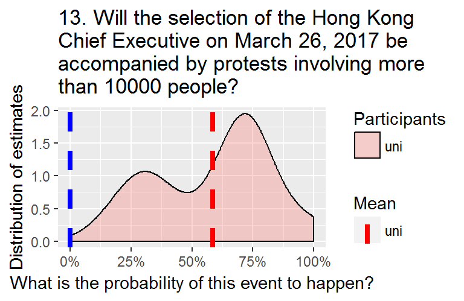

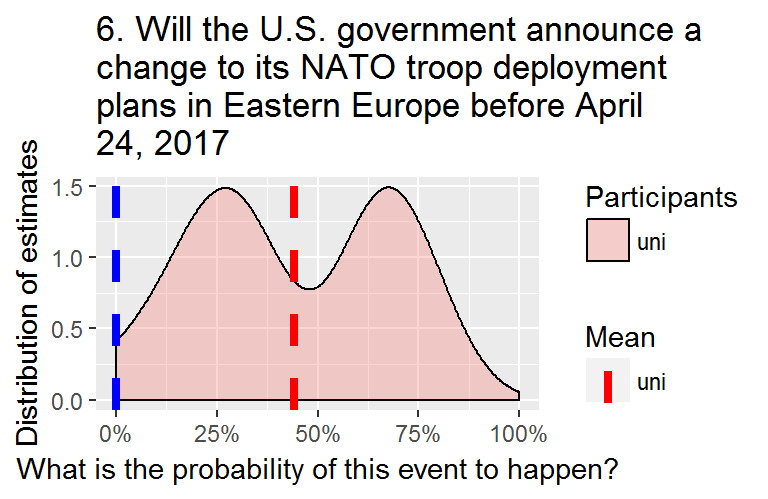

## Score distribution

- Score: Brier score
  - intuition: closeness to truth
  - mathematical: squared errors
- Hertie students compared to other participants

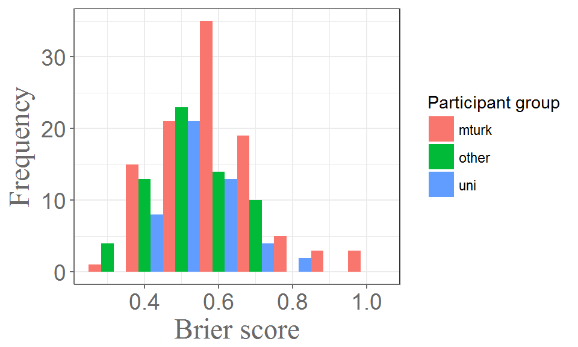

## The research in the background

data used for testing, e.g.

- **Hypothesis 2: The marginal added value of time spend on forecasting is positive and decreases over time**

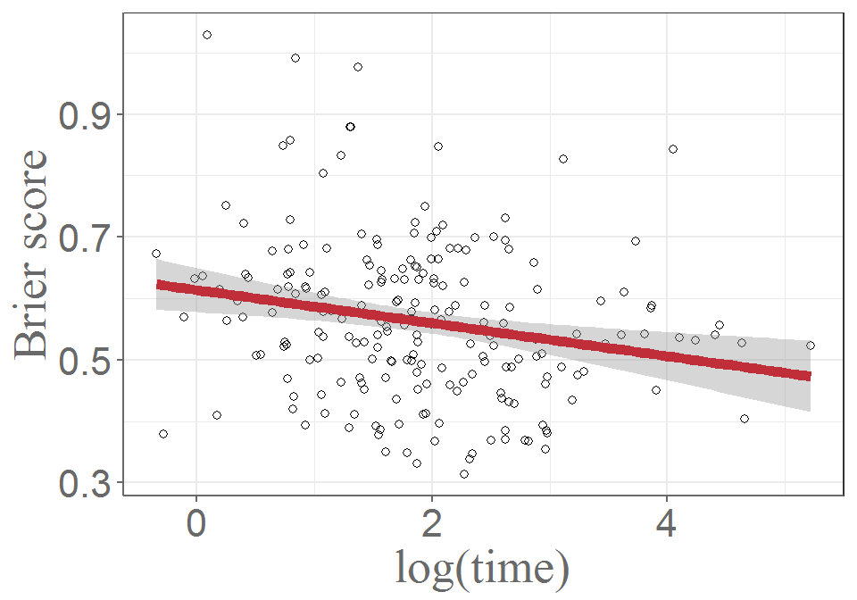

## Scoreboard

| HertieID | brier.avg | rank |
| --- | --- | --- |
| 164485 | 0.3801667 | 1 |
| 167828 | 0.3842833 | 2 |
| 161531 | 0.3844417 | 3 |
| 161721 | 0.3933417 | 4 |
| 163476 | 0.3971250 | 5 |
| 165656 | 0.4288583 | 6 |
| 168247 | 0.4343500 | 7 |
| 167957 | 0.4445333 | 8 |
| 162694 | 0.4508750 | 9 |
| 168772 | 0.4609750 | 10 |

## Questions

Thank you for your attention